# Exposure dataset in Python

- Show All Code
- Hide All Code
- View Source

Independent replication of the R pipeline · Heatwaves, ozone and mortality in Santiago, 2009-2020

Author

Amaru Agüero Jiménez

Published

November 25, 2026

## 1 Purpose

This page rebuilds the exposure dataset in Python, from the same raw inputs and the same `config/config.yml`, and then compares the result with the R dataset column by column. Two implementations that agree are the strongest check available that the indicators are what the analysis plan describes. Nothing computed by the R pipeline is reused; the only files taken from it are the station and target coordinates, which exist only inside R data files and are exported as they are by `Code/15_export_geodata.R`.

Replicated here: the 15 heatwave indicators, the delivered air pollution series with their quality rules, the ozone station series from the hourly SINCA records (24-hour mean and MDA8), their interpolation to the municipalities by inverse distance weighting, and the high-ozone flags. Ordinary kriging is not replicated: its variogram is fitted by the R package `automap`, which has no Python counterpart, so the kriging columns exist only in the R dataset.

```python
import hashlib
from pathlib import Path

import geopandas as gpd
import matplotlib.pyplot as plt
import numpy as np
import pandas as pd
import yaml

ROOT = next(p for p in [Path.cwd(), *Path.cwd().parents] if (p / "_quarto.yml").exists())
DERIVED = ROOT / "Data" / "Derived"


def merge_config(base, override):
    """Entries of `override` replace those of `base`, level by level."""
    out = dict(base)
    for key, value in override.items():
        if isinstance(value, dict) and isinstance(out.get(key), dict):
            out[key] = merge_config(out[key], value)
        else:
            out[key] = value
    return out


CFG = yaml.safe_load((ROOT / "config" / "config.yml").read_text(encoding="utf-8"))
LOCAL = ROOT / "config" / "local.yml"
if LOCAL.exists():
    CFG = merge_config(CFG, yaml.safe_load(LOCAL.read_text(encoding="utf-8")))


def get_param(*keys):
    """Read one parameter; stop when it is missing or still null."""
    value = CFG
    for key in keys:
        if not isinstance(value, dict) or value.get(key) is None:
            raise KeyError(f"Parameter {'$'.join(keys)} is not set in config/config.yml")
        value = value[key]
    return value


MANIFEST = pd.read_csv(ROOT / "Data" / "input_manifest.csv", dtype=str)
VERIFIED = set()


def verify_input(name, path):
    """Stop unless the input is, byte for byte, the file listed in Data/input_manifest.csv."""
    if name in VERIFIED:
        return
    expected = MANIFEST[MANIFEST["input"] == name]
    if expected.empty:
        raise KeyError(f"Input '{name}' is not listed in Data/input_manifest.csv")
    for row in expected.itertuples():
        file = path / row.file if path.is_dir() else path
        if not file.exists():
            raise FileNotFoundError(f"Input '{name}': file not found: {file}")
        digest = hashlib.md5(usedforsecurity=False)
        with open(file, "rb") as handle:
            for block in iter(lambda: handle.read(1 << 20), b""):
                digest.update(block)
        if file.stat().st_size != int(row.bytes) or digest.hexdigest() != row.md5:
            raise ValueError(f"Input '{name}' is not the file the results were produced from: {file}")
    VERIFIED.add(name)


def input_path(name):
    root = Path(get_param("paths", "input_root")).expanduser()
    if not root.is_absolute():
        root = ROOT / root
    path = Path(get_param("inputs", name)).expanduser()
    if not path.is_absolute():
        path = root / path
    if not path.exists():
        raise FileNotFoundError(f"Input '{name}' not found: {path}")
    verify_input(name, path)
    return path


municipalities = pd.read_csv(ROOT / get_param("study", "municipalities_file"))
assert len(municipalities) == get_param("study", "n_municipalities")
CODES = municipalities["code"].tolist()
STUDY_YEARS = get_param("study", "years")
WARM_MONTHS = get_param("study", "warm_season_months")
LAG_BUFFER = max(get_param("design", "lags_days"))
KEEP_DATES = pd.date_range(
    pd.Timestamp(f"{STUDY_YEARS[0]}-01-01") - pd.Timedelta(days=LAG_BUFFER),
    f"{STUDY_YEARS[1]}-12-31", freq="D", name="date",
)

# Figure style shared with the R reports
INK = {"primary": "#0b0b0b", "secondary": "#52514e", "grid": "#e1e0d9", "surface": "#fcfcfb"}
BLUE, ORANGE, AQUA = "#2a78d6", "#eb6834", "#1baf7a"
plt.rcParams.update({
    "figure.facecolor": INK["surface"], "axes.facecolor": INK["surface"],
    "axes.edgecolor": INK["grid"], "axes.grid": True, "grid.color": INK["grid"],
    "grid.linewidth": 0.5, "axes.spines.top": False, "axes.spines.right": False,
    "axes.labelcolor": INK["secondary"], "xtick.color": INK["secondary"],
    "ytick.color": INK["secondary"], "text.color": INK["primary"],
    "axes.titleweight": "bold", "axes.titlesize": 10, "axes.titlelocation": "left",
    "font.size": 9,
})
# The figures are stored as PNG at 600 dpi, on every machine and whatever
# picture format the report options ask for
from matplotlib_inline.backend_inline import set_matplotlib_formats
set_matplotlib_formats("png", dpi=600)
```

## 2 Temperature and heatwave indicators

```python
def read_cr2met(path, codes):
    """Wide CR2MET file -> table of days (rows) by municipality (columns)."""
    raw = pd.read_csv(path, header=None)
    header, body = raw.iloc[:4], raw.iloc[4:]
    assert (header.iloc[:, :3] == -9999).all().all()
    file_codes = header.iloc[0, 3:].astype(int).tolist()
    missing = set(codes) - set(file_codes)
    if missing:
        raise ValueError(f"Municipalities missing from {path.name}: {sorted(missing)}")
    dates = pd.to_datetime(dict(year=body[0].astype(int), month=body[1].astype(int),
                                day=body[2].astype(int)))
    assert dates.is_monotonic_increasing and dates.is_unique
    columns = [3 + file_codes.index(code) for code in codes]
    wide = body.iloc[:, columns].astype(float)
    wide.index, wide.columns = pd.DatetimeIndex(dates, name="date"), codes
    assert not wide.isna().any().any() and (wide > -90).all().all()
    return wide


def fill_calendar(wide, handling):
    """Complete calendar; only isolated 29 February gaps are accepted."""
    full = pd.date_range(wide.index.min(), wide.index.max(), freq="D", name="date")
    out = wide.reindex(full)
    filled = out.iloc[:, 0].isna()
    gaps = full[filled]
    assert ((gaps.month == 2) & (gaps.day == 29)).all(), "gaps other than 29 February"
    if handling == "interpolate":
        neighbours = (out.shift(1) + out.shift(-1)) / 2
        out.loc[filled.to_numpy()] = neighbours.loc[filled.to_numpy()]
    elif handling != "missing":
        raise ValueError(handling)
    return out, filled


handling = get_param("temperature", "leap_day_handling")
tmax, filled = fill_calendar(read_cr2met(input_path("cr2met_tmax"), CODES), handling)
tmin, _ = fill_calendar(read_cr2met(input_path("cr2met_tmin"), CODES), handling)

ref_years = get_param("temperature", "percentile_reference_years")
percentiles = get_param("temperature", "percentile_thresholds")
durations = get_param("temperature", "min_consecutive_days")
absolute_c = get_param("temperature", "absolute_threshold_celsius")
season_rule = get_param("temperature", "percentile_season")
assert season_rule in ("all_year", "warm_season")

in_reference = (tmax.index.year >= ref_years[0]) & (tmax.index.year <= ref_years[1]) & ~filled.to_numpy()
threshold_days = in_reference & (tmax.index.month.isin(WARM_MONTHS) if season_rule == "warm_season" else True)
# numpy's default (linear) quantile is R's type 7
thresholds = {p: np.quantile(tmax[threshold_days].to_numpy(), p / 100, axis=0) for p in percentiles}


def flag(condition, source):
    """0/1 table that keeps missing values missing."""
    return condition.astype(float).where(source.notna())


def consecutive_flag(hot, n):
    """1 when the day is at least the n-th consecutive hot day, by municipality."""
    run = hot.rolling(n).sum()          # each column is one municipality
    return flag(run == n, run)


temperature_columns = {"tmax": tmax, "tmin": tmin}
hot = {f"p{p}": flag(tmax > thresholds[p], tmax) for p in percentiles}
hot[f"{absolute_c}c"] = flag(tmax > absolute_c, tmax)
for name, table in hot.items():
    temperature_columns[f"hot_{name}"] = table
    for n in durations:
        temperature_columns[f"hw_{name}_{n}d"] = consecutive_flag(table, n)

if get_param("temperature", "include_ehf"):
    tad = (tmax + tmin.shift(-1)) / 2
    tad_reference = np.nanquantile(tad[in_reference].to_numpy(),
                                   get_param("temperature", "ehf_reference_percentile") / 100, axis=0)
    accl = tad.rolling(get_param("temperature", "ehf_acclimatisation_days")).mean()
    temperature_columns["tad"] = tad
    for n in durations:
        mean_n = tad.rolling(n).mean()
        ehf = (mean_n - tad_reference) * np.maximum(1, mean_n - accl)
        temperature_columns[f"ehf_{n}d"] = ehf
        temperature_columns[f"hw_ehf_{n}d"] = flag(ehf > 0, ehf)


def to_long(tables):
    """Dictionary of day-by-municipality tables -> one row per municipality-day."""
    parts = [t.loc[KEEP_DATES].rename_axis(index="date", columns="com").stack(future_stack=True).rename(name)
             for name, t in tables.items()]
    return pd.concat(parts, axis=1).reset_index()


exposure = to_long(temperature_columns)
exposure["temp_filled"] = exposure["date"].isin(filled.index[filled])
print(f"{len(exposure):,} municipality-days, "
      f"{sum(c.startswith('hw_') for c in exposure.columns)} heatwave indicators")
```

```
144,738 municipality-days, 15 heatwave indicators
```

## 3 Delivered air pollution series

```python
variables = ([get_param("air_pollution", "primary_pollutant")]
             + get_param("air_pollution", "adjustment_pollutants")
             + get_param("air_pollution", "other_variables"))
assert get_param("air_pollution", "negative_values") == "set_missing"
min_stations = get_param("air_pollution", "min_stations")

suffixes = ["_idw", "_ok", "_ok_var", "_n_estaciones"]
columns = ["comuna", "date"] + [v + s for v in variables for s in suffixes]
version = get_param("air_pollution", "series_version_main")
delivered = pd.read_csv(input_path(f"sinca_{version}"), usecols=columns, parse_dates=["date"])
delivered = delivered[delivered["date"].isin(KEEP_DATES)]
delivered = delivered.merge(municipalities, left_on="comuna", right_on="name", validate="m:1")
assert len(delivered) == len(CODES) * len(KEEP_DATES)
delivered = delivered.rename(columns={"code": "com"}).drop(columns=["comuna", "name"])
delivered.columns = [c.replace("_n_estaciones", "_n_stations") for c in delivered.columns]

for v in variables:
    for method in ("idw", "ok"):
        column = f"{v}_{method}"
        drop = (delivered[column] < 0) | (delivered[column].notna() & (delivered[f"{v}_n_stations"] < min_stations))
        delivered.loc[drop, column] = np.nan
        if method == "ok":
            delivered.loc[drop, f"{v}_ok_var"] = np.nan

exposure = exposure.merge(delivered, on=["com", "date"], validate="1:1")
```

## 4 Ozone rebuilt from the hourly records

```python
rules = get_param("station_series")
station_codes = pd.read_csv(ROOT / rules["stations_file"])
accepted = rules["accepted_status"]
status_column = {"validated": 2, "preliminary": 3, "not_validated": 4}
assert set(accepted) <= set(status_column)


def station_daily(sinca_id):
    """24-hour mean and MDA8 of one station from its hourly records."""
    file = input_path("sinca_hourly_dir") / (rules["hourly_file_pattern"] % sinca_id)
    raw = pd.read_csv(file, sep=";", header=None, skiprows=1, dtype=str, usecols=range(5))
    value = pd.Series(np.nan, index=raw.index)
    for status in ("validated", "preliminary", "not_validated"):     # validated first
        if status in accepted:
            number = pd.to_numeric(raw[status_column[status]].str.replace(",", ".", regex=False))
            value = value.fillna(number)
    stamp = pd.to_datetime(raw[0], format="%y%m%d") + pd.to_timedelta(raw[1].str[:2].astype(int), unit="h")
    assert stamp.is_unique
    hourly = pd.Series(value.to_numpy(), index=stamp)
    full = pd.date_range(stamp.min().normalize(), stamp.max().normalize() + pd.Timedelta(hours=23), freq="h")
    hourly = hourly.reindex(full)
    valid = hourly.notna()
    n8 = valid.astype(float).rolling(8).sum()
    mean8 = (hourly.fillna(0).rolling(8).sum() / n8).where(n8 >= rules["mda8_min_hours_window"])
    day = hourly.index.normalize()
    n_hours = valid.groupby(day).sum()
    mean24 = hourly.groupby(day).mean().where(n_hours >= rules["min_valid_hours_day"])
    mda8 = mean8.groupby(day).max().where(mean8.notna().groupby(day).sum() >= rules["mda8_min_windows_day"])
    return pd.DataFrame({"mean24": mean24, "mda8": mda8}).reindex(KEEP_DATES)


daily = {row.station: station_daily(row.sinca_id) for row in station_codes.itertuples()}
print({name: int(table["mean24"].notna().sum()) for name, table in daily.items()})
```

```
{'Independencia': 3915, 'La Florida': 3972, 'Las Condes': 4252, "Parque O'Higgins": 4031, 'Pudahuel': 4053, 'Cerrillos I': 2802, 'El Bosque': 4131, 'Cerro Navia': 4100, 'Puente Alto': 4037, 'Talagante': 3849, 'Quilicura I': 2606}
```

```python
params = get_param("interpolation")
points = pd.read_csv(DERIVED / "ozone_station_points.csv").set_index("station").loc[list(daily)]
targets = pd.read_csv(DERIVED / "interpolation_points.csv").set_index("com").loc[CODES]
distance = np.hypot(targets["x"].to_numpy()[:, None] - points["x"].to_numpy()[None, :],
                    targets["y"].to_numpy()[:, None] - points["y"].to_numpy()[None, :])


def idw_day(values):
    """Inverse distance weighting of one day of station values to the targets:
    the nearest `idw_nmax` stations within `idw_maxdist_m`, power `idw_power`."""
    available = ~np.isnan(values)
    if available.sum() < params["ok_min_stations"]:
        return np.full(len(targets), np.nan), int(available.sum())
    d = distance[:, available]
    d = np.where(d <= params["idw_maxdist_m"], d, np.inf)
    nearest = np.argsort(d, axis=1)[:, :params["idw_nmax"]]
    d_near = np.take_along_axis(d, nearest, axis=1)
    weights = 1 / d_near ** params["idw_power"]            # zero beyond the search radius
    total = weights.sum(axis=1)
    estimate = (weights * values[available][nearest]).sum(axis=1)
    return np.where(total > 0, estimate / np.where(total > 0, total, 1), np.nan), int(available.sum())


rebuilt = {}
for metric, prefix in {"mean24": "o3obs", "mda8": "o3mda8"}.items():
    station_values = np.column_stack([daily[name][metric].to_numpy() for name in daily])
    results = [idw_day(row) for row in station_values]
    rebuilt[f"{prefix}_idw"] = pd.DataFrame([r[0] for r in results], index=KEEP_DATES, columns=CODES)
    n_stations = pd.DataFrame(np.repeat([[r[1]] for r in results], len(CODES), axis=1),
                              index=KEEP_DATES, columns=CODES)
    rebuilt[f"{prefix}_n_stations"] = n_stations

rebuilt_long = pd.concat(
    [t.rename_axis(index="date", columns="com").stack(future_stack=True).rename(name)
     for name, t in rebuilt.items()], axis=1).reset_index()
exposure = exposure.merge(rebuilt_long, on=["com", "date"], validate="1:1")
```

## 5 High-ozone flags and compound exposure

```python
exposure = exposure.sort_values(["com", "date"]).reset_index(drop=True)
exposure["year"] = exposure["date"].dt.year
exposure["in_study_period"] = exposure["year"].between(*STUDY_YEARS)
exposure["warm_season"] = exposure["date"].dt.month.isin(WARM_MONTHS)
analysis_day = exposure["in_study_period"] & exposure["warm_season"]
cutoffs = get_param("air_pollution", "ozone_percentile_cutoffs")
assert get_param("air_pollution", "ozone_percentile_scope") == "municipality"

for series in ["o3_idw", "o3_ok", "o3obs_idw", "o3mda8_idw"]:
    reference = exposure.loc[analysis_day & exposure[series].notna()]
    for p in cutoffs:
        cut = reference.groupby("com")[series].quantile(p / 100)       # linear, as R type 7
        exposure[f"{series}_gt_p{p}"] = flag(exposure[series] > exposure["com"].map(cut), exposure[series])

exposure.to_csv(DERIVED / "py_exposure_2009_2020.csv", index=False)
print(f"{exposure.shape[0]:,} rows, {exposure.shape[1]} columns written to Data/Derived/py_exposure_2009_2020.csv")
```

```
144,738 rows, 63 columns written to Data/Derived/py_exposure_2009_2020.csv
```

## 6 Comparison with the R dataset

Every column built here is compared with the column of the same name in `Data/Derived/exposure_2009_2020.csv`, over all 144,738 municipality-days.

```python
r_data = pd.read_csv(DERIVED / "exposure_2009_2020.csv", parse_dates=["date"])
r_data = r_data.sort_values(["com", "date"]).reset_index(drop=True)
assert (r_data[["com", "date"]].to_numpy() == exposure[["com", "date"]].to_numpy()).all()

groups = {
    "Temperature (tmax, tmin, tad)": ["tmax", "tmin", "tad"],
    "Hot-day flags": [c for c in exposure if c.startswith("hot_")],
    "Heatwave indicators, percentile and 30 °C": [c for c in exposure if c.startswith("hw_") and "ehf" not in c],
    "Excess heat factor": [c for c in exposure if c.startswith("ehf_")],
    "Heatwave indicators, EHF": [c for c in exposure if c.startswith("hw_ehf_")],
    "Delivered series, IDW and kriging": [f"{v}_{m}" for v in variables for m in ("idw", "ok", "ok_var")],
    "Rebuilt ozone, 24-hour mean, IDW": ["o3obs_idw"],
    "Rebuilt ozone, MDA8, IDW": ["o3mda8_idw"],
    "Stations per day": [c for c in exposure if c.endswith("_n_stations")],
    "High-ozone flags, delivered series": [c for c in exposure if "_gt_p" in c and c.startswith("o3_")],
    "High-ozone flags, rebuilt series": [c for c in exposure if "_gt_p" in c and not c.startswith("o3_")],
}
rows = []
for label, columns in groups.items():
    py = exposure[columns].astype(float).to_numpy()
    r = r_data[columns].astype(float).to_numpy()
    both = ~np.isnan(py) & ~np.isnan(r)
    difference = np.abs(py - r)[both]
    rows.append({
        "Columns": label, "Number of columns": len(columns), "Values compared": int(both.sum()),
        "Missing in one only": int((np.isnan(py) != np.isnan(r)).sum()),
        "Largest absolute difference": float(difference.max()),
        "Values differing by more than 1e-6": int((difference > 1e-6).sum()),
    })
comparison = pd.DataFrame(rows)
comparison.style.format({"Values compared": "{:,}", "Largest absolute difference": "{:.2e}"}).hide(axis="index")
```

Table 1: Python against R, column by column. Flags and counts are compared exactly; continuous variables by their largest absolute difference.

| Columns | Number of columns | Values compared | Missing in one only | Largest absolute difference | Values differing by more than 1e-6 |
| --- | --- | --- | --- | --- | --- |
| Temperature (tmax, tmin, tad) | 3 | 434,214 | 0 | 7.11e-15 | 0 |
| Hot-day flags | 4 | 578,952 | 0 | 0.00e+00 | 0 |
| Heatwave indicators, percentile and 30 °C | 12 | 1,736,856 | 0 | 0.00e+00 | 0 |
| Excess heat factor | 3 | 434,214 | 0 | 6.09e-13 | 0 |
| Heatwave indicators, EHF | 3 | 434,214 | 0 | 0.00e+00 | 0 |
| Delivered series, IDW and kriging | 12 | 1,736,734 | 0 | 0.00e+00 | 0 |
| Rebuilt ozone, 24-hour mean, IDW | 1 | 144,658 | 0 | 3.38e-11 | 0 |
| Rebuilt ozone, MDA8, IDW | 1 | 144,640 | 0 | 4.18e-11 | 0 |
| Stations per day | 6 | 868,428 | 0 | 0.00e+00 | 0 |
| High-ozone flags, delivered series | 6 | 868,308 | 0 | 0.00e+00 | 0 |
| High-ozone flags, rebuilt series | 6 | 867,894 | 0 | 0.00e+00 | 0 |

```python
identical = (comparison["Missing in one only"].sum() == 0
             and comparison["Values differing by more than 1e-6"].sum() == 0)
print("Python and R agree on every compared value." if identical
      else "Python and R differ: see the table above.")
```

```
Python and R agree on every compared value.
```

## 7 Two figures from the Python dataset

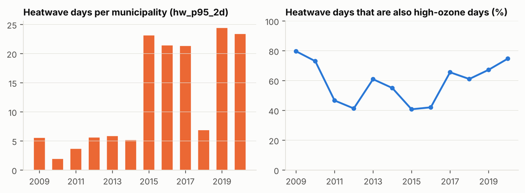

Figure 1: Heatwave days per municipality and high-ozone share of heatwave days, by calendar year, working definitions.

```python
heatwave_main = get_param("models", "heatwave_main")
ozone_flag_main = (f"{get_param('air_pollution', 'ozone_series_main')}_"
                   f"{get_param('air_pollution', 'interpolation_method_main')}_gt_p"
                   f"{get_param('models', 'ozone_cutoff_main')}")
days = exposure[exposure["in_study_period"] & exposure["warm_season"]]
assert len(days) == len(CODES) * days["date"].nunique()
by_year = days.groupby("year").apply(lambda d: pd.Series({
    "heatwave": d[heatwave_main].sum() / d["com"].nunique(),
    "share": 100 * (d[heatwave_main] * d[ozone_flag_main]).sum() / d[heatwave_main].sum(),
}), include_groups=False)

fig, axes = plt.subplots(1, 2, figsize=(8, 3))
axes[0].bar(by_year.index, by_year["heatwave"], width=0.6, color=ORANGE)
axes[0].set_title(f"Heatwave days per municipality ({heatwave_main})")
axes[1].plot(by_year.index, by_year["share"], color=BLUE, linewidth=2, marker="o", markersize=4)
axes[1].set_title("Heatwave days that are also high-ozone days (%)")
axes[1].set_ylim(0, 100)
for ax in axes:
    ax.set_xticks(range(STUDY_YEARS[0], STUDY_YEARS[1] + 1, 2))
    ax.grid(axis="x", visible=False)
fig.tight_layout()
plt.show()
```

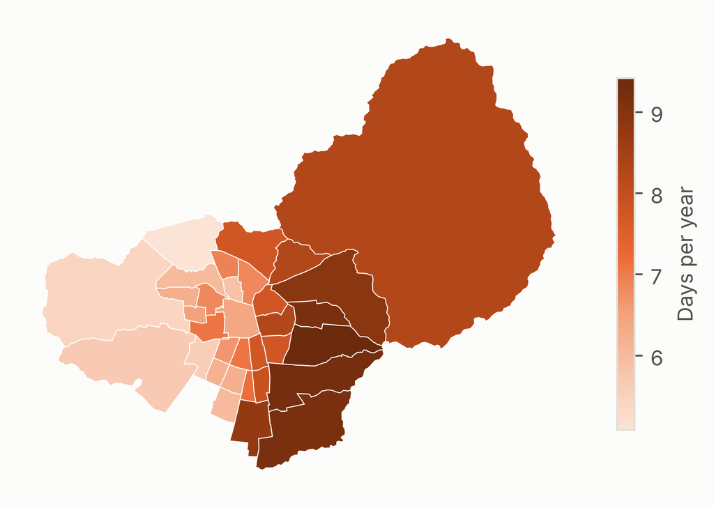

Figure 2: Compound days per year by municipality (heatwave and high ozone), warm seasons 2009-2020, working definitions.

```python
polygons = gpd.read_file(DERIVED / "municipality_polygons.geojson")
compound = (days.assign(both=days[heatwave_main] * days[ozone_flag_main])
            .groupby("com")["both"].sum() / (STUDY_YEARS[1] - STUDY_YEARS[0] + 1))
polygons["compound"] = polygons["com"].map(compound)
from matplotlib.colors import LinearSegmentedColormap
orange_ramp = LinearSegmentedColormap.from_list(
    "orange", ["#fbe3d6", "#f7c4aa", "#f2a17b", "#eb6834", "#c4501f", "#983b13", "#6c2a0d"])
fig, ax = plt.subplots(figsize=(5.5, 4.6))
polygons.plot(column="compound", cmap=orange_ramp, edgecolor="white", linewidth=0.4, ax=ax,
              legend=True, legend_kwds={"label": "Days per year", "shrink": 0.6})
ax.set_axis_off()
plt.show()
```

## 8 Software

```python
import platform
print("Python", platform.python_version())
for module in (np, pd, gpd, yaml):
    print(module.__name__, module.__version__)
```

```
Python 3.13.18
numpy 2.5.3
pandas 3.0.5
geopandas 1.2.0
yaml 6.0.3
```